# Forecasting Covid-19 Vaccination Rate

## Task

**The data is obtained from https://github.com/owid/covid-19-data/blob/master/public/data/owid-covid-data.csv**

This is part of the assignment for the unit FIT3164 (Data Science Project), which required myself and another team member to investigate the date in which Australia itself will reach 80% first dose vaccinated and 80% fully vaccinated.

The main reason why we have decided to investigate the vaccination rate within Australia is because of the following that was said by the prime minister on Fri 30 Jul 2021:

“All but the most highly targeted lockdowns will end and the country will begin to reopen its international borders once 80 per cent of eligible Australians are fully vaccinated against COVID-19”, Prime Minister Scott Morrison says.

By identifying when we as a whole will reach the 80% fully vaccinated rate within Australia through the use of forecasting, we can determine when we are able to end lockdown and relive our lives again.

This can be further explored at https://covidplus.github.io/website/Rate.html

### (Preview) Forecasting (80% First Dose Vaccinated)

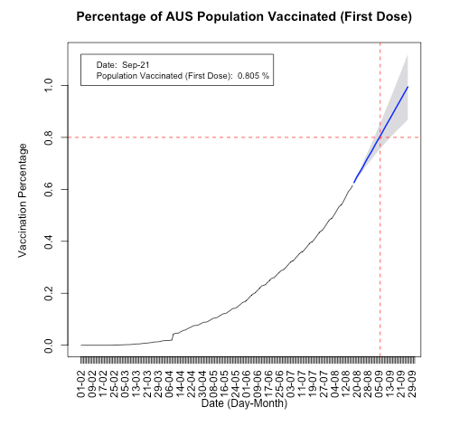